# Statistical learning and linear models

Day 12

## What is Statistical Learning?

- In general, statistical learning entails learning about the behavior of one variable from other variables
- Imagine we observe data for variable \(Y\) along with other variables \(X=(X_1,X_2,...,X_p)\)
- If we assume there is some relationship between \(Y\) and \(X\), we can write the very general form
  - \(Y = f(X) + \epsilon\)
    - \(f(X)\) refers to a mathematical function
    - \(\epsilon\) refers to a random error term

## What is Statistical Learning?

- What does the `random` error term \(\epsilon\) represent?
  - Theoretically, all the things we have no hope of predicting
- What properties should it have?
  - mean \(0\). Why?
  - independent of \(X\). Why?
- What are some examples of \(Y = f(X) + \epsilon\)?
  - \(Y\)=grade, \(X_1\)=effort, \(X_2\)=prior knowledge, \(X_3\)=good netflix shows, \(\epsilon\)=getting sick
  - \(Y\)=salary, \(X_1\)=education, \(X_2\)=age, \(X_3\)=major, \(X_4\)=family resources, \(\epsilon\)=luck with interview

## What is Statistical Learning?

- Statistical learning: `estimating` \(f(X)\)
- Why should we estimate \(f(X)\)?
1. Prediction
   - \(\hat{Y}\) = predicted Y
   - \(\hat{Y} = \hat{f}(X)\) because our best prediction for \(\epsilon\) is 0
   - For prediction we don’t really care what form \(\hat{f}(X)\) takes, it can be a `black box`.
2. Inference
   - Actually understanding how changes in \(X\) affect \(Y\) (more prevelant in Economics)
   - Ex: how much my grade will go up if I spend 1 more hour studying for the exam?

## Inference vs Prediction

- Let’s analyze the relationship between test score and hours studied

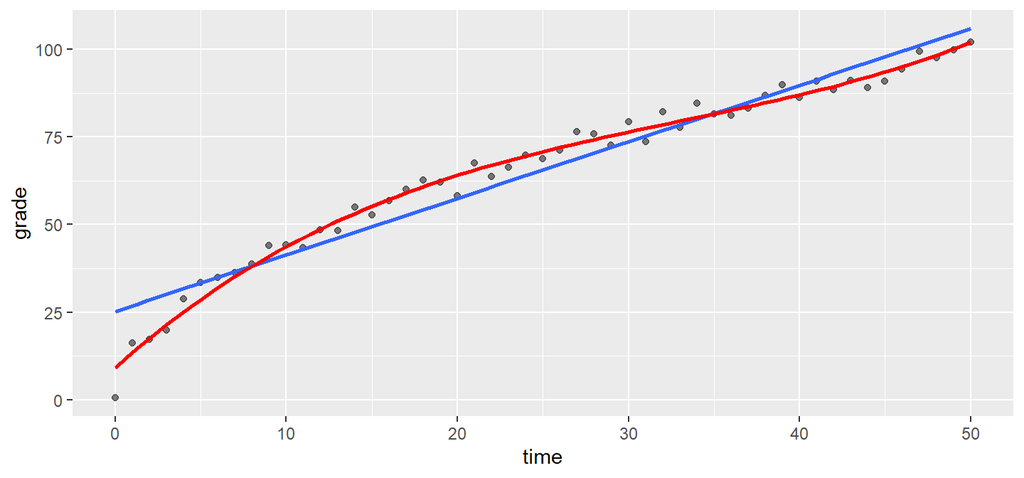

```r
> time=(0:50)
> sim_data <- data.frame(time,grade=14*time^(0.5)+rnorm(length(time),0,2))
> ggplot(data=sim_data,aes(x=time,y=grade)) + geom_point(alpha=0.5) + geom_smooth(method="lm",se=FALSE) +
+    geom_smooth(method="lm",formula=y ~ poly(x,3,raw=TRUE),se=FALSE,color="red")
```

## Inference

- Q: How much will my score improve if I study 1 more hour?

```r
> lm_output <- lm(grade~time,data=sim_data) %>% print()

Call:
lm(formula = grade ~ time, data = sim_data)

Coefficients:
(Intercept)         time
     25.215        1.613
```

- \(grade = 25.22 + 1.61 \times time\)
- \(\frac{d(grade)}{d(time)}=1.61\)

## Prediction

- Q: What will my grade be if I study for \(x\) hours?
- Let’s use a more flexible model - adding \(x^2 \text{and }x^3\) terms

```r
> lm_output_flex <- lm(grade ~ poly(time, 3, raw = TRUE), data = sim_data) %>% print()

Call:
lm(formula = grade ~ poly(time, 3, raw = TRUE), data = sim_data)

Coefficients:
               (Intercept)  poly(time, 3, raw = TRUE)1
                  9.190725                    4.361441
poly(time, 3, raw = TRUE)2  poly(time, 3, raw = TRUE)3
                 -0.101528                    0.001028
```

- \(grade = 9.19 + 4.36 \times time -0.1 \times time^2 + 0.00103 \times time^3\)
- \(\frac{d(grade)}{d(time)}=4.36 -0.1\times 2time + 0.00103\times 3time^2\)
- If we just want to predict scores, our more flexible model is better
- However, if we want to perform inference, the relationship between \(grade\) and \(time\) is now more complex

## When to focus on prediction vs inference?

It really depends on the question we are trying to answer

- Inference
  - **How does one extra year of school affect wages?**
  - We **really** want to understand the relationship between the two variables because we want to inform policy
  - Does one extra year of schooling result in higher wages, or do smarter people (who are predisposed to higher wages) just get more schooling?
    - Has implications for policy
- Prediction
  - **Which emails are spam?**
  - As long as the spam filter works, we don’t really care what is going on under the hood
  - More common in the private sector where you just want it to work

## Assessing Model Accuracy

- We will be working with many different models in this class
  - we need a way to assess their performance
- Since our models generate predictions, one obvious criteria is how good those predictions are
- `mean squared error` (MSE) calcualtes the average squared error of the predictions
  - \(MSE = \frac{1}{n} \sum^n_{i=1} (y_i-\hat{f}(x_i))^2\)
  - Why do we need to take the square?
    - Want to penalize both over- and under- estimates
    - Squared has nice mathematical properties but you could also use absolute value

## Fitting a very simple model

- Let’s go back to our test and hours data

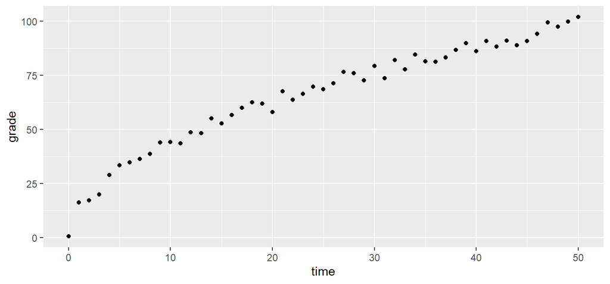

```r
> ggplot(data=sim_data,aes(x=time,y=grade)) + geom_point(alpha=1)
```

- The simplest model has one parameter that isn’t even a function of \(X\)
  - \(Y = f(X) + \epsilon = \mu + \epsilon\)

## Fitting a very simple model

- If we want to minimize the `MSE`, what should we set \(\hat{\mu}\) to?
- Let’s just choose 50

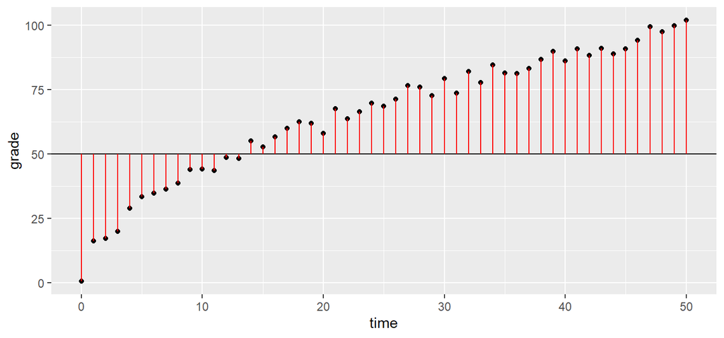

```r
> sim_data$predicted=50
> ggplot(data=sim_data,aes(x=time,y=grade)) + geom_point(alpha=1)  + geom_hline(aes(yintercept=predicted)) + geom_segment(aes(xend=time,yend=predicted),color="red")
```

- \(MSE = \frac{1}{n} \sum^n_{i=1} (y_i-50)^2 =\) 841.07

## Fitting a very simple model

- We can use math to solve for the best predictor
- Choose the \(\mu\) that minimizes the `MSE`: \(min_\mu(\frac{1}{n} \sum^n_{i=1} (y_i-\mu)^2)\)
- Take the derivative with respect to \(\mu\): \(\frac{dMSE}{d\mu}=\frac{-2}{n}\sum^n_{i=1} (y_i-\mu)\)
- Set it to zero: \(\frac{-2}{n}\sum^n_{i=1} (y_i-\mu)=0\)

\[ \begin{aligned} \sum^n_{i=1} (y_i-\mu)&=0 \\ \sum^n_{i=1}y_i&=\sum^n_{i=1}\mu \\ \sum^n_{i=1}y_i&=n\times \mu \\ \mu=\frac{1}{n}\sum^n_{i=1}y_i&=mean(y_i) \end{aligned} \]

## Fitting a very simple model

- Now we know the `mean` is the best predictor if we have to choose one number
  - Intuitively this makes sense because by construction the mean is the expected value

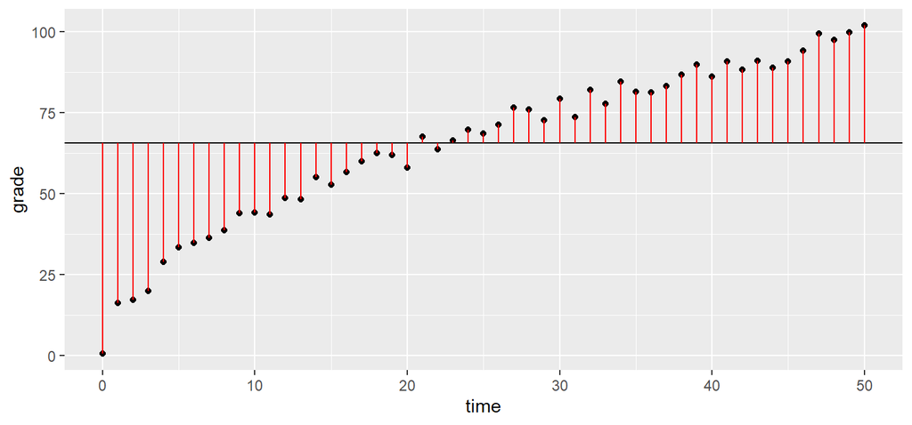

```r
> sim_data$predicted2=mean(sim_data$grade)
> ggplot(data=sim_data,aes(x=time,y=grade)) + geom_point(alpha=1)  + geom_hline(aes(yintercept=predicted2)) + geom_segment(aes(xend=time,yend=predicted2),color="red")
```

- \(MSE = \frac{1}{n} \sum^n_{i=1} (y_i-\hat{\mu})^2 =\) 599.75

## Introducing more complexity: Linear regression

- The case where we have 1 parameter that isn’t a function of \(X\) is instructive but not practical
- We can increase our flexibility by adding one parameter that is a function of \(X\)
  - General formula for Statistical Learning is \(Y = f(X) + \epsilon\)
  - `univariate linear regression` is \(f(X)=\beta_0 + X\beta_1\)
  - Our new model is then \(Y = \beta_0 + X\beta_1 + \epsilon\)
- How do we estimate \(\beta_0\) and \(\beta_1\)?
  - Minimize `MSE`: \(min_{\beta_0,\beta_1}(\frac{1}{n} \sum^n_{i=1} (y_i-(\beta_0+X\beta_1))^2)\)
  - \(\hat{\beta_1}=\frac{\sum^n_{i=1}(x_i-\bar{x})(y_i-\bar{y})}{\sum^n_{i=1}(x_i-\bar{x})^2}=\frac{cov(X,Y)}{var(X)}\)
  - \(\hat{\beta_0}=\bar{y}-\hat{\beta_1}\bar{x}\)

## Introducing more complexity: Linear regression

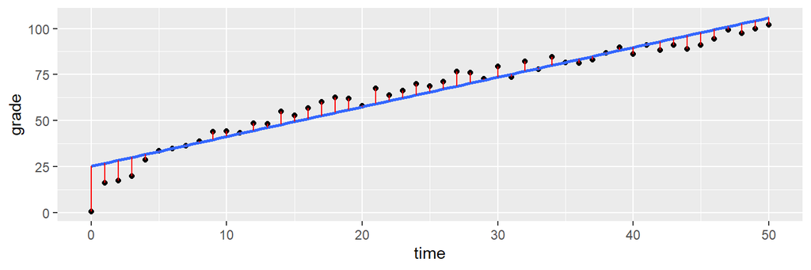

```r
> lm_output <- lm(grade~time,data=sim_data) %>% print()

Call:
lm(formula = grade ~ time, data = sim_data)

Coefficients:
(Intercept)         time
     25.215        1.613
> sim_data$predicted3=lm_output$fitted.values
> ggplot(data=sim_data,aes(x=time,y=grade)) + geom_point(alpha=1)  + geom_smooth(method="lm",se=FALSE) + geom_segment(aes(xend=time,yend=predicted3),color="red")
```

- \(MSE = \frac{1}{n} \sum^n_{i=1} (y_i-(\hat{\beta_0}+X\hat{\beta}_1)^2) =\) 36.18

## Why not just have the most flexible model?

- We see that increasing flexibility will always reduce the `MSE`.
- Why shouldn’t we always increase flexibility?
- We need to distinguish between `training` and `testing` data
  - `training` data is the data we use to fit the model (eg. I might use data from this class)
  - `testing` data is the data that we want to predict outcomes for (eg. next semester a student asks me to predict their grade)
- Other examples:
  - `train` model on past stock market behavior: goal is to `predict` future behavior
  - `train` model on what factors are correlated with crime: `predict` future behavior

## The problem of `over-fitting`

- A very flexible model will tend to `over-fit` the training data. Why?
- This happens because the flexible model tends to fit all the random indiosyncracies of the training data
- Ex: Imagine I want to predict where college students like to shop
  - An inflexible model would only allow me to use type of outlet: online, brick and mortor, on campus, etc.
  - A very flexible model would allow me to capture exactly which outlets: Amazon, Hot Topic, Urban Outfitters
  - While this may capture the habits of CMC students, it may be too specific to generalize to other college students
- What’s the point? As we venture into the land of many models, there exists a delicate balance between `improved fit` from flexibility and risk of `over-fitting`